# Population and Lyme Disease Prevalence in Maine

# 1 Introduction

In order to determine the regions of Maine with the greatest risk associated with Lyme disease, it is important to understand where Lyme disease cases are most often reported as well as how the population of Maine is distributed across the state. While it is nearly impossible to gather tick population data, comparing human population numbers to Lyme disease prevalence data may provide valuable insight into where ticks tend to congregate as well as the risk of contracting Lyme disease in different parts of the state.

# 2 Data

## 2.1 Tickborne Diseases

Lyme disease prevalence data from 2019-2022 for the state of Maine is publicly available on the University of Maine website. Data for several other tickborne diseases is also available on the website.

### UMaine 2019 Season Prevalence Data By Town

|  | town | year | borrelia_percent | borrelia_positive | borrelia_tests | anaplasma_percent | anaplasma_positive | anaplasma_tests | babesia_percent | babesia_positive | babesia_tests | ehrlichia_percent | ehrlichia_positive | ehrlichia_tests | francisella_percent | francisella_positive | francisella_tests | rickettsia_percent | rickettsia_positive | rickettsia_tests |
| --- | --- | --- | --- | --- | --- | --- | --- | --- | --- | --- | --- | --- | --- | --- | --- | --- | --- | --- | --- | --- |
| 1 | Abbot | 2019 | 0% | 0 | 0 | 0% | 0 | 0 | 0% | 0 | 0 | 0% | 0 | 0 | 0% | 0 | 0 | 0% | 0 | 0 |
| 2 | Acton | 2019 | 0% | 0 | 2 | 0% | 0 | 2 | 50% | 1 | 2 | 0% | 0 | 0 | 0% | 0 | 0 | 0% | 0 | 0 |
| 3 | Adamstown Twp | 2019 | 0% | 0 | 0 | 0% | 0 | 0 | 0% | 0 | 0 | 0% | 0 | 0 | 0% | 0 | 0 | 0% | 0 | 0 |
| 4 | Addison | 2019 | 0% | 0 | 0 | 0% | 0 | 0 | 0% | 0 | 0 | 0% | 0 | 0 | 0% | 0 | 0 | 0% | 0 | 0 |
| 5 | Albany Twp | 2019 | 0% | 0 | 0 | 0% | 0 | 0 | 0% | 0 | 0 | 0% | 0 | 0 | 0% | 0 | 0 | 0% | 0 | 0 |
| 6 | Albion | 2019 | 0% | 0 | 1 | 0% | 0 | 1 | 0% | 0 | 1 | 0% | 0 | 0 | 0% | 0 | 0 | 0% | 0 | 0 |
| 7 | Alder Brook Twp | 2019 | 0% | 0 | 0 | 0% | 0 | 0 | 0% | 0 | 0 | 0% | 0 | 0 | 0% | 0 | 0 | 0% | 0 | 0 |
| 8 | Alder Stream Twp | 2019 | 0% | 0 | 0 | 0% | 0 | 0 | 0% | 0 | 0 | 0% | 0 | 0 | 0% | 0 | 0 | 0% | 0 | 0 |
| 9 | Alexander | 2019 | 0% | 0 | 0 | 0% | 0 | 0 | 0% | 0 | 0 | 0% | 0 | 0 | 0% | 0 | 0 | 0% | 0 | 0 |
| 10 | Alfred | 2019 | 50% | 1 | 2 | 50% | 1 | 2 | 0% | 0 | 2 | 0% | 0 | 0 | 0% | 0 | 0 | 0% | 0 | 0 |

[output cut: 907 more lines]

### Maine Tracking Network Rate of Tickborne Disease by Town 2016-2020

|  | Location | Anaplasmosis | Babesiosis | Lyme | Population |
| --- | --- | --- | --- | --- | --- |
| 1 | Abbot | 0 | 0 | * | 3515 |
| 2 | Acton | 124.7 | 7.8 | 101.3 | 12831 |
| 3 | Addison | 0 | 0 | 176.7 | 6224 |
| 4 | Albion | 38.5 | 19.3 | 308.3 | 10379 |
| 5 | Alexander | 0 | 0 | * | 2380 |
| 6 | Alfred | 77.3 | 6.4 | 141.8 | 15519 |
| 7 | Allagash | 0 | 0 | 0 | 1069 |
| 8 | Alna | 359.7 | * | 470.4 | 3614 |
| 9 | Alton | 0 | 0 | * | 4485 |
| 10 | Amherst | 0 | 0 | 0 | 1392 |

[output cut: 523 more lines]

### Number of Tickborne Disease Cases by Town 2016-2020

|  | Location | Anaplasmosis | Babesiosis | Lyme | Population |
| --- | --- | --- | --- | --- | --- |
| 1 | Abbot | 0 | 0 | &lt;6 | 3515 |
| 2 | Acton | 16 | 1 | 13 | 12831 |
| 3 | Addison | 0 | 0 | 11 | 6224 |
| 4 | Albion | 4 | 2 | 32 | 10379 |
| 5 | Alexander | 0 | 0 | &lt;6 | 2380 |
| 6 | Alfred | 12 | 1 | 22 | 15519 |
| 7 | Allagash | 0 | 0 | 0 | 1069 |
| 8 | Alna | 13 | &lt;6 | 17 | 3614 |
| 9 | Alton | 0 | 0 | &lt;6 | 4485 |
| 10 | Amherst | 0 | 0 | 0 | 1392 |

[output cut: 523 more lines]

## 2.2 Population

Population data for the state of Maine is publicly available via the U.S. Census Bureau records. This data exists in several different spatial capacities, so determining the most useful spatial unit is very important when working with the data. The data itself can be imported using a unique API key in RStudio.

### Importing population data from the U.S. Census Bureau

```r
# apply unique census api key
census_api_key("5177724b01a7fe4714097e711cb95230c37cfce7", install = TRUE, overwrite = TRUE)

# import census data
## spatial unit --> place
## variable of interest --> population
census_place_df <- get_acs(geography = "place", variables = c("B01003_001E"), state = "ME", geometry = TRUE)

# import census data
## spatial unit --> county subdivision
## variable of interest --> population
census_county_sub_df <- get_acs(geography = "county subdivision", variables = c("B01003_001E"), state = "ME", geometry = TRUE)
```

### Census data using “place” spatial unit

|  | GEOID | Place | State | variable | estimate | moe | geometry |
| --- | --- | --- | --- | --- | --- | --- | --- |
| 1 | 2327085 | Gardiner | Maine | B01003_001 | 5657 | 20 | {'type': 'MultiPolygon', 'coordinates': [[[[-69.85453, 44.168315], [-69.850017, 44.169434], [-69.848087, 44.170515], [-69.847855, 44.171894], [-69.846056, 44.172803], [-69.844791, 44.175482], [-69.840… |
| 2 | 2360825 | Presque Isle | Maine | B01003_001 | 9116 | 22 | {'type': 'MultiPolygon', 'coordinates': [[[[-68.056528, 46.775677], [-68.009457, 46.776839], [-67.989211, 46.777307], [-67.968335, 46.777804], [-67.926079, 46.778765], [-67.923262, 46.722241], [-67.92… |
| 3 | 2345845 | Millinocket | Maine | B01003_001 | 4287 | 17 | {'type': 'MultiPolygon', 'coordinates': [[[[-68.743008, 45.667217], [-68.707142, 45.673605], [-68.703075, 45.674336], [-68.686308, 45.677294], [-68.686013, 45.676596], [-68.682261, 45.67713], [-68.681… |
| 4 | 2345250 | Mexico | Maine | B01003_001 | 1701 | 178 | {'type': 'MultiPolygon', 'coordinates': [[[[-70.55641, 44.570817], [-70.555954, 44.571296], [-70.555332, 44.570513], [-70.5543, 44.570934], [-70.55164, 44.5682], [-70.551549, 44.567902], [-70.552076, … |
| 5 | 2342485 | Madawaska | Maine | B01003_001 | 2769 | 228 | {'type': 'MultiPolygon', 'coordinates': [[[[-68.3534703326205, 47.3572335794832], [-68.343007, 47.35824], [-68.3370986383111, 47.3595968900349], [-68.336236, 47.359795], [-68.329879, 47.36023], [-68.3… |
| 6 | 2301675 | Ashland | Maine | B01003_001 | 573 | 141 | {'type': 'MultiPolygon', 'coordinates': [[[[-68.423137, 46.611116], [-68.420806, 46.614264], [-68.419062, 46.62198], [-68.41468, 46.630442], [-68.418126, 46.631895], [-68.418454, 46.631961], [-68.4171… |
| 7 | 2324285 | Fairfield | Maine | B01003_001 | 3027 | 482 | {'type': 'MultiPolygon', 'coordinates': [[[[-69.626823, 44.580491], [-69.615654, 44.594036], [-69.61065, 44.598208], [-69.605361, 44.600498], [-69.599951, 44.60158], [-69.594003, 44.601698], [-69.5948… |
| 8 | 2309585 | Calais | Maine | B01003_001 | 2993 | 31 | {'type': 'MultiPolygon', 'coordinates': [[[[-67.305472, 45.144826], [-67.298209, 45.146672], [-67.296174, 45.147952], [-67.294881, 45.149666], [-67.294363, 45.153506], [-67.296979, 45.155267], [-67.30… |
| 9 | 2317705 | Dixfield | Maine | B01003_001 | 1345 | 242 | {'type': 'MultiPolygon', 'coordinates': [[[[-70.461647, 44.541645], [-70.459507, 44.543518], [-70.456929, 44.54509], [-70.458295, 44.549061], [-70.457474, 44.552054], [-70.455756, 44.552181], [-70.452… |
| 10 | 2388160 | York Harbor | Maine | B01003_001 | 2522 | 373 | {'type': 'MultiPolygon', 'coordinates': [[[[-70.680916, 43.145163], [-70.671643, 43.149264], [-70.664555, 43.151106], [-70.651483, 43.159468], [-70.645664, 43.155774], [-70.641145, 43.153605], [-70.63… |

[output cut: 120 more lines]

### Census data using “county subdivision” spatial unit

|  | GEOID | Place | County | State | variable | estimate | moe | geometry |
| --- | --- | --- | --- | --- | --- | --- | --- | --- |
| 1 | 2300541067 | Long Island | Cumberland County | Maine | B01003_001 | 314 | 91 | {'type': 'MultiPolygon', 'coordinates': [[[[-70.156463, 43.710482], [-70.15529, 43.712277], [-70.1495519551655, 43.7145653918831], [-70.1444432942795, 43.7120856612472], [-70.146253, 43.708119], [-70.… |
| 2 | 2301709550 | Byron | Oxford County | Maine | B01003_001 | 100 | 48 | {'type': 'MultiPolygon', 'coordinates': [[[[-70.769228, 44.732228], [-70.61503, 44.795634], [-70.563799, 44.713193], [-70.706441, 44.65345], [-70.739445, 44.695267], [-70.769228, 44.732228]]]]} |
| 3 | 2301978780 | Veazie | Penobscot County | Maine | B01003_001 | 1999 | 174 | {'type': 'MultiPolygon', 'coordinates': [[[[-68.730812, 44.854967], [-68.720882, 44.863738], [-68.716551, 44.860491], [-68.698968, 44.847362], [-68.696187, 44.845266], [-68.696899, 44.844507], [-68.70… |
| 4 | 2301913365 | Clifton | Penobscot County | Maine | B01003_001 | 844 | 181 | {'type': 'MultiPolygon', 'coordinates': [[[[-68.570506, 44.805644], [-68.55986, 44.817585], [-68.51673, 44.865595], [-68.473014, 44.870763], [-68.454889, 44.80155], [-68.445219, 44.763014], [-68.52854… |
| 5 | 2301918580 | Drew Plantation | Penobscot County | Maine | B01003_001 | 30 | 26 | {'type': 'MultiPolygon', 'coordinates': [[[[-68.166816, 45.620379], [-68.048012, 45.639897], [-68.020354, 45.553285], [-68.109847, 45.538589], [-68.111893, 45.539987], [-68.111685, 45.544197], [-68.10… |
| 6 | 2300358060 | Perham | Aroostook County | Maine | B01003_001 | 394 | 74 | {'type': 'MultiPolygon', 'coordinates': [[[[-68.299992, 46.872676], [-68.30018, 46.875061], [-68.300155, 46.926445], [-68.178696, 46.92886], [-68.17832, 46.913618], [-68.178394, 46.912079], [-68.17824… |
| 7 | 2302913750 | Columbia | Washington County | Maine | B01003_001 | 435 | 127 | {'type': 'MultiPolygon', 'coordinates': [[[[-67.892057, 44.699158], [-67.777174, 44.717408], [-67.78151, 44.732974], [-67.771673, 44.734795], [-67.759786, 44.696002], [-67.760634, 44.694084], [-67.759… |
| 8 | 2300342450 | Macwahoc Plantation | Aroostook County | Maine | B01003_001 | 97 | 44 | {'type': 'MultiPolygon', 'coordinates': [[[[-68.299858, 45.625075], [-68.299385, 45.673065], [-68.16619, 45.673309], [-68.166816, 45.620379], [-68.180354, 45.618015], [-68.260136, 45.604483], [-68.257… |
| 9 | 2302703950 | Belfast | Waldo County | Maine | B01003_001 | 6688 | 16 | {'type': 'MultiPolygon', 'coordinates': [[[[-69.118282, 44.429828], [-69.040547, 44.46544], [-69.040252, 44.465569], [-68.981191, 44.492011], [-68.978225, 44.488851], [-68.981452, 44.487303], [-68.977… |
| 10 | 2301100590 | Albion | Kennebec County | Maine | B01003_001 | 2217 | 208 | {'type': 'MultiPolygon', 'coordinates': [[[[-69.513987, 44.494512], [-69.493542, 44.56092], [-69.481788, 44.559329], [-69.479657, 44.566322], [-69.443184, 44.561338], [-69.446955, 44.576349], [-69.444… |

[output cut: 522 more lines]

### Spatial unit differences

Differences in the size and coverage of data points from the Census data can be visualized using static spatial plots. Although the “place” data does a good job displaying the major population centers of Maine, the “county subdivision” data appears to have more complete coverage of the state.

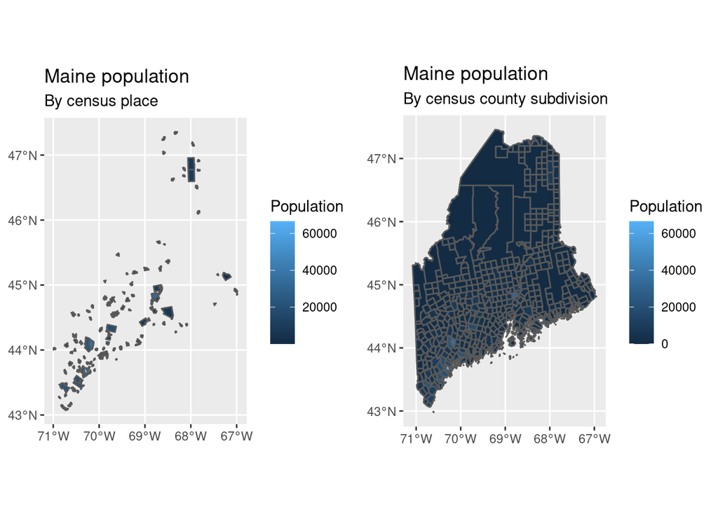

### Population and Tick Prevalence Leaflet

The population data and the tick prevalence data can be explored relative to one another on the interactive leaflet plot shown below. It is interesting to see that the majority of the tick cases in the data are located on the coast, and not necessarily in the largest population centers in the state.

[interactive chart not shown]